# StatsQuest Notes

Jason Kunisaki

# Description

This document contains notes taken from Josh Starmer’s StatsQuest [Youtube channel](https://www.youtube.com/c/joshstarmer/videos?view=0&sort=da&flow=grid).

- The folder, **~/git/notes/statsquest/img/** contains the images from the video that will be embedded in this document.

## [Linear Regression and Linear Models](https://www.youtube.com/watch?v=PaFPbb66DxQ&list=PLblh5JKOoLUIzaEkCLIUxQFjPIlapw8nU)

### Fitting a line to data AKA least squares AKA linear regression

- Get data points and draw horizontal line around the *mean* of the data
- Subtract the value of the horizontal line (y=b) from the y-coordinates of the datapoints:
  - $total = (b-y1) + (b-y2) + (b-y3) + (b-y4) + (b-y5)$
  - **NOTE:** In this example, *y4* and *y5* are greater than *b* –> this will subtract the value from the total –> would make the overall fit appear better than it really is
    - When total = 0 –> the line fits the data points perfectly
    - When total >>> 0 –> the line does not fit the data points all that well
  - Square the values of each difference to ensure each term is positive: $total = (b-y1)^2 + (b-y2)^2 + (b-y3)^2 + (b-y4)^2 + (b-y5)^2$
    - Called the *sum of squared residuals*
    - The distance between the line and the data point is called a **residual**
  - Rotate the line and calculate the *sum of squared residuals* –> use the line that has the lowest value for the best fit
- **How to find the line of best fit**
  - $y = a*x + b$ –> find optimal values for *a* and *b* to minimize *sum of squared residuals*
  - *sum of squared residuals* $= ((a*x_1 + b) - y_1)^2 + (a*x_2 + b) - y_2)^2 + ...)$
    - $a*x_1 + b$ –> value of the best fit line at $x_1$
    - $y_1$ –> observed value at $x_1$
  - There is a point when the *sum of squared residuals* is at its lowest depending on the slope of the line
    - Take the derivative of the function that provides the values of *sum of squared residuals* given a slope
    - Look for the slope when the derivative = 0
    - Different slope and intercept values will alter the *sum of squared residual* values –> see how different slopes/y-intercept values for the line of best fit alter the sum of square residuals values (i.e. define slope and alter y-intercepts points and vice versa)
- **Take Home Points**
  - Goal is to minimize the square of distances b/w the observed values and the line
  - Take derivative of sum of squared residuals with different slopes –> find where it is equal to 0
  - Final line minimizes sums of squares between the line itself and the real data

##### Horizontal Line

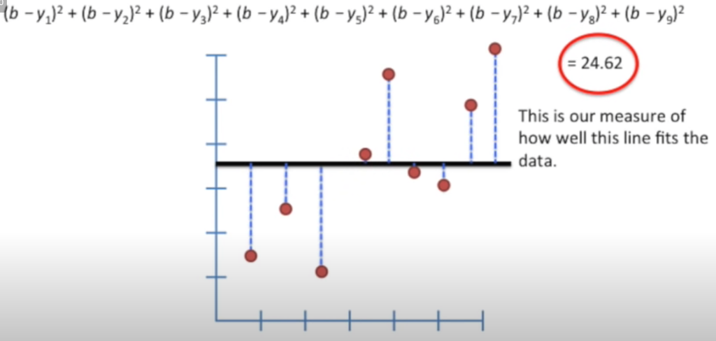

##### Line of least squared residuals

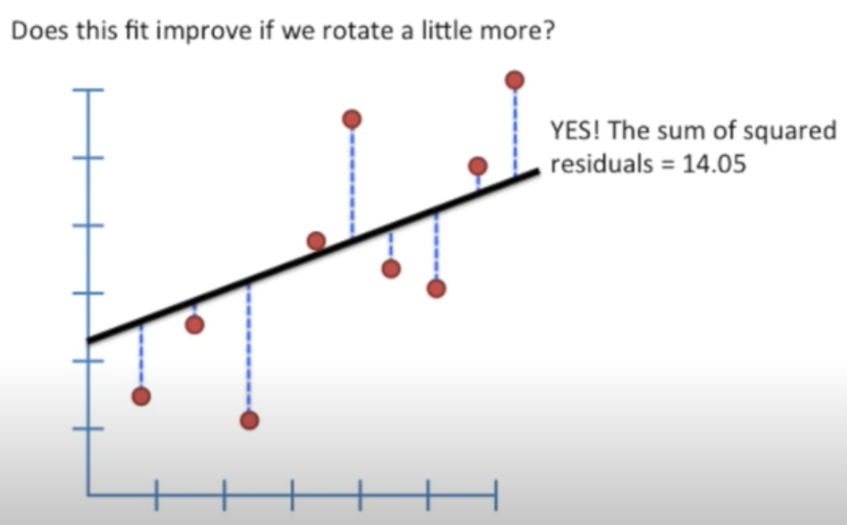

##### Finding line of best fit

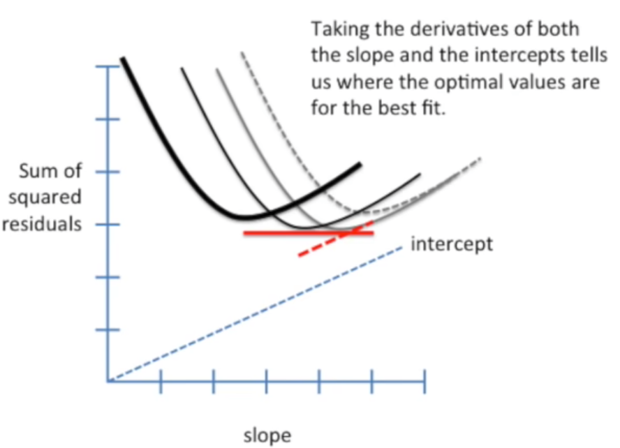

### R-squared explained

- Metric of correlation
- Variation of the data = $\frac{\sum_{i}(mouse weight_i - mean/line)^2}{n}$
  - Variance is the average sum of squares per sample
  - See below for example
- **R^2 –> quantifies how much better of *line of best fit* fits the data better than a line on the data’s mean**
  - $R^2 = \frac{var(mean) - var(line)}{var(mean)}$
  - **NOTE:** variation around the line should never be greater than variation around the mean
  - $R^2$ quantifies the decrease in variation around the line relative to the total variation around the mean
    - $R^2 = 81%$ –> there is 81% less variation around the line than the mean
    - The size/weight relationship (see below example) accounts for 81% of the variation
- **“The statistically significant $R^2$ was 0.9” –> The relationship b/w two variables explains 90% of the variation in the data and something else explains the remaining 10%**
- **How is R^2 related to R?**
  - $R^2$ is the square of R
  - **“The statistically significant R was 0.9” –> The relationship b/w the two variables explains 81% ($0.9 * 0.9$) of the variation in the data…**
  - It is not easy to determine how much better of a correlation b/w variables with just R
    - $R = 0.7$ and $R^2 = 0.5$ –> 50% of the variation is explained
    - $R = 0.5$ and $R^2 = 0.25$ –> 25% of the variation is explained
    - $R^2$ shows that the first correlation is **twice** as good as the second
  - **NOTE:** $R^2$ does not indicate the direction of the correlation
- **Main Ideas**
1. $R^2$ is the percentage of variation explained by the relationship between two variables
2. Just square R to get $R^2$

##### Variation of the data

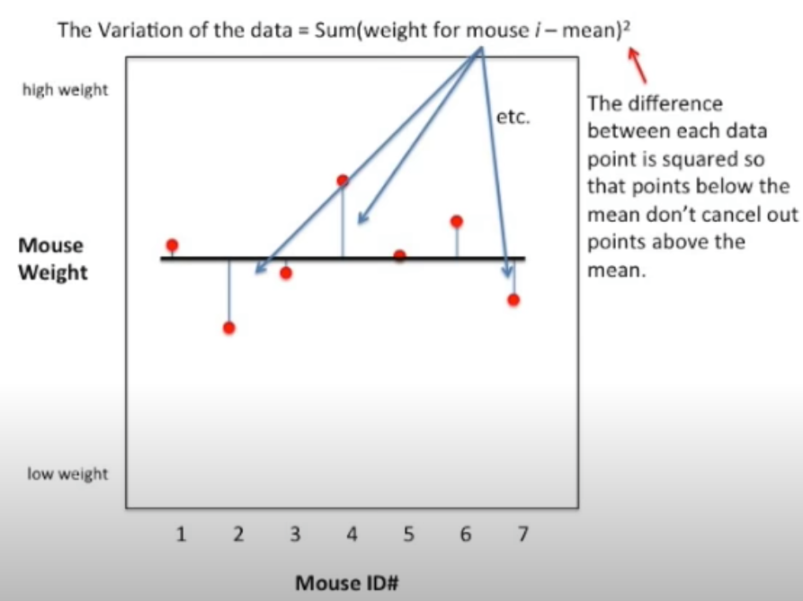

##### Example with R^2 (positive example)

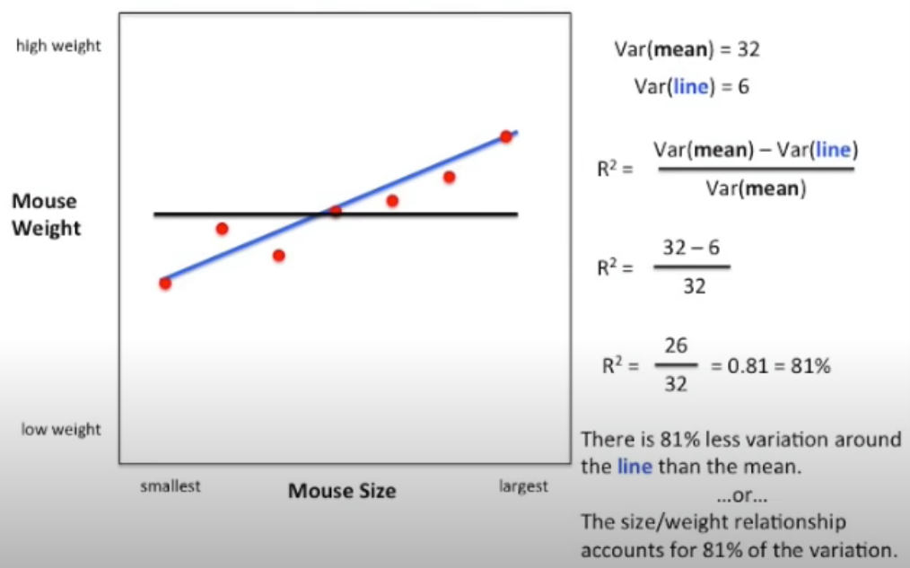

##### Example with R^2 (negative example)

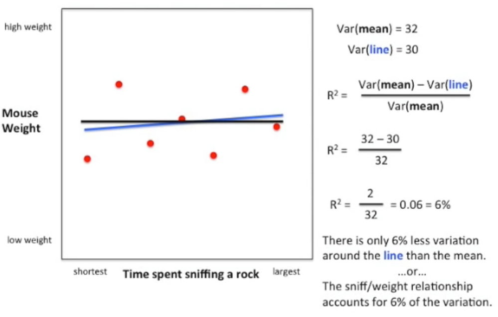

##### Variance calculation example

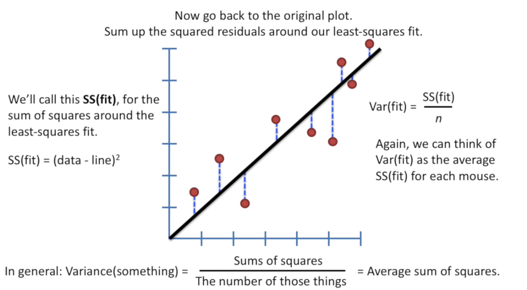

### Linear Regression (Pt. 1)

- **Main Ideas:**
  1. Use least-squares to fit a line to the data
  2. Calculate $R^2$
  3. Calculate *p-value* for $R^2$
- Adding another variable/parameter to line of best fit equation will never make *sum of squared residules* around *line of best fit* (SS(fit)) worse than equations with fewer variables/parameters (see below)
  - Adding more parameters to equation –> more opportunities for random events to affect SS(fit) –> change $R^2$
  - Adjusted $R^2$ –> scale $R^2$ by number of parameters
- **How to determine if $R^2$ is significant**
  - p-value derived from $F = \frac{var(explained by mouse weight)}{var(not explained by mouse weight)}$
  - Variation in mouse size explained by weight –> same as reduction in variance when we take weight into account ($R^2$)
  - Variation in mouse size not explained by weight
  - $F = \frac{SS(mean) - SS(fit)/(p_{fit} - p_{mean})}{SS(fit)/(n - p_{fit})}$
    - $p_{fit}$ = number of parameters in the fit line (y = mx + b) –> has 2 parameters: y-intercept and slope
    - $p_{mean}$ = number of parameters in the mean line (y = b) –> has 1 parameter: y-intercept
    - $n$ = number of samples
    - Numerator = variance explained by extra parameter (i.e. variance in mouse size explained by mouse weight)
  - In the above examples:
    - The “fit” line has 1 more parameter than the mean line: slope
    - Slope describes the relationship b/w weight and size
    - $p_{fit} - p_{mean}$ = 2 - 1 = 1 –> the “fit” has one extra parameter: mouse weight…
  - **Why divide SS(fit) by $n - p_{fit}$ instead of just $n$?????**
    - When more parameters are used in the “fit” equation –> need more data to estimate them
    - Ex: Only need two points to estimate a line BUT need 3 points to estimate a plane
  - **How to convert F-statistic into p-value:** (see below)
    - Calculate F-statistic values for a randomly generated dataset
    - Repeat above simulations and plot F-statistic value in a histogram
    - p-value = number of extreme values / total number of values
    - **NOTE:** p-values will be smaller when there are more samples relative to the number of parameters in the fit equation (recall $(n-p_{fit})$)
- **Main Ideas Revisited:**
- Linear regression quantifies relationship in the data via $R^2$
- Linear regression determines how reliable that relationship is with the *p-value calculated from the F-statistic*

##### Add parameters

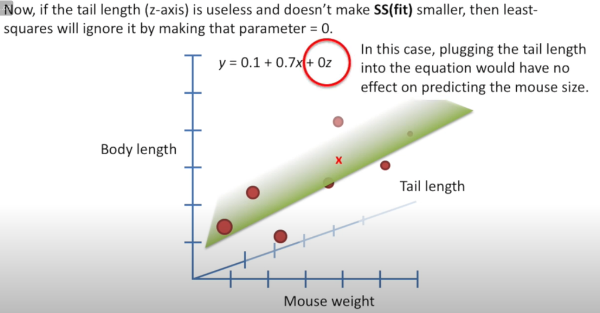

##### Summary of $R^2$

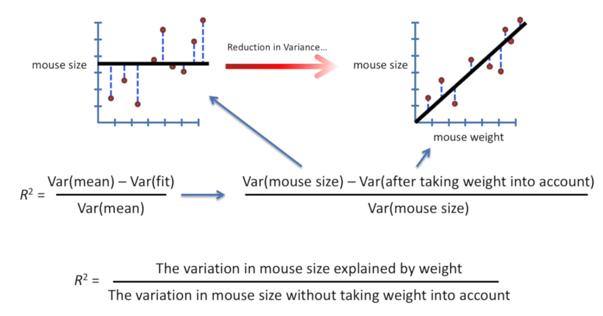

##### F-stat –> p-value

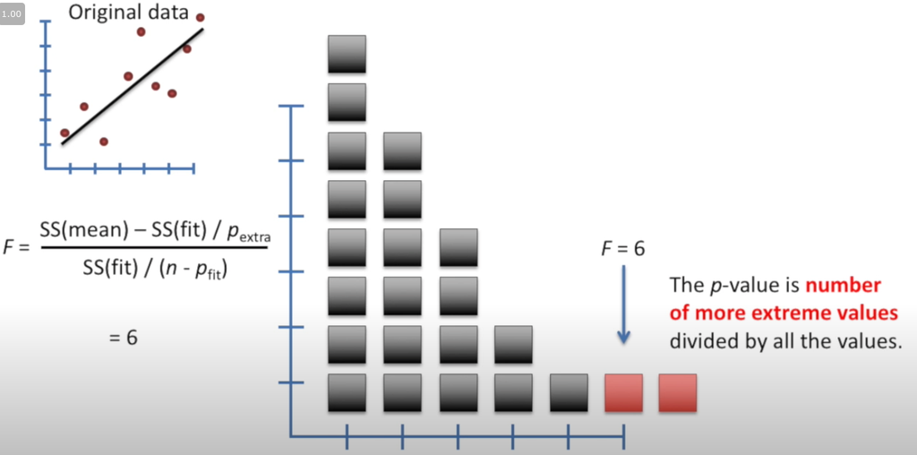

### Doing Linear Regression in R

#### Results of regression summary:

- **Residuals:** Summary of residuals (distance from data to fitted line). Should be symmetrically distributed around the line.
- **Coefficients:** Provides least-square estimates for the fitted line
  - y-intercept and slope values
  - **Std. Error** and **t-value** show how **p-values** were calculated
  - p-value tests if the values for y-intercept and slope are equal to 0 –> if so, the variable used does not have much use in the model
- **Residual standard error:** Square root of the denominator in the equation for F.
- **Multiple R-squared:** simply $R^2$ as described above –> weight can explain ##% of variation in the mouse size.
- **Adjusted R-squared:** $R^2$ scaled by the number of parameters in the model
- **F-statistic:** provides:
  1. F-statistic value
  2. Degrees of freedom
  3. p-value

```r
mouse_data <- data.frame(
  weight = rnorm(n = 100, mean = 10, sd = 1),
  size = rnorm(n=100, mean = 15, sd = 2)
)

## lm stands for linear models
mouse_regression <- lm(size ~ weight, data = mouse_data)
```

##### Summary of regression data

```r
summary(mouse_regression)
```

```
##
## Call:
## lm(formula = size ~ weight, data = mouse_data)
##
## Residuals:
##     Min      1Q  Median      3Q     Max
## -3.9771 -1.0113 -0.2616  1.0402  4.9812
##
## Coefficients:
##             Estimate Std. Error t value Pr(>|t|)
## (Intercept)  13.9738     1.9235   7.265 9.07e-11 ***
## weight        0.1303     0.1913   0.681    0.497
## ---
## Signif. codes:  0 '***' 0.001 '**' 0.01 '*' 0.05 '.' 0.1 ' ' 1
##
## Residual standard error: 1.836 on 98 degrees of freedom
## Multiple R-squared:  0.004714,   Adjusted R-squared:  -0.005442
## F-statistic: 0.4641 on 1 and 98 DF,  p-value: 0.4973
```

##### Plot

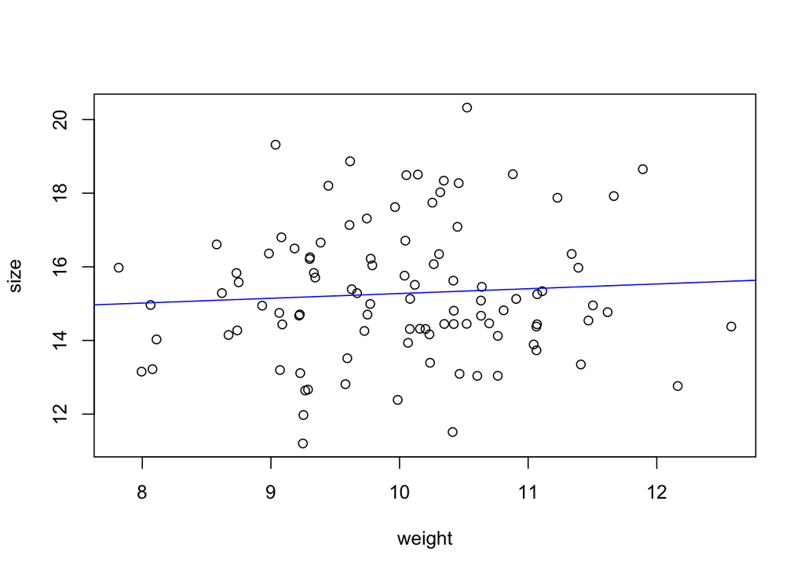

```r
plot(mouse_data)
abline(mouse_regression, col = "blue")
```

### Multiple Regression (Pt. 1.5)